# R Notebook

The purpose of this exercise is to design and implement an entire data preparation pipeline in R. We would like you to implement a robust, extensible and generic framework for data preparation.

```r
# Install packages

packages <- c("gamlss", "gamlss.add", "gamlss.dist", "DT", "roll", "dplyr", "stats", "tseries", "ggpubr", "psych", "magrittr", "labelVector", "corrplot")

install.packages(setdiff(packages, rownames(installed.packages())))

# load libraries
library(gamlss)
library(gamlss.add)
library(gamlss.dist)
library(DT)
library(roll)
library(dplyr)
library(stats)
library(tseries)
library(ggpubr)
library(psych)
library(magrittr)
library(labelVector)
library(corrplot)
```

1. Take as raw inputs to the data preparation process, the oil data from the gamlss package.

```r
# create function to pass rawdata
data_preparation_process <- function(rawdata) {
  oil_data <- rawdata
  return(oil_data)
}

oil_data <- data_preparation_process(gamlss.data::oil)

paste0("The data set has ", nrow(oil_data), " observations and  ", ncol(oil_data), " variables. ")

# columns names (oil)
cat('\n')
oil_col_names <- colnames(oil_data)
cat('Columns in the data frame: \n\n')

for (i in (1:ncol(oil))) {print(paste0("Column number: ",i, ". Variable name: ", oil_col_names[i]))}
# paste0("Variable name: ", col_names)
```

[output not shown]

2. Develop a process that allows us to add additional drivers which are transformations of the raw input timeseries. Include the following transformations:
1. Rolling standard deviation (of arbitrary window)
2. Rolling mean (of arbitrary window)
3. Lagging (of arbitrary order)
4. Leading (of arbitrary order)
5. Differencing
6. Spread (between two input drivers)
7. Ratio (between two input drivers)
8. Product (between two input drivers)

(*) Below we create one function, where user can pass any input time series and the result will generate below columns

roll_std_dev (Rolling standard deviation) roll_mean (Rolling mean) lag_1 (Lagging) lead (Leading) diff (Differencing) [Note: no value given for window, assume daily data so selected window is 7, similary for lag, lead and differencing selected order is 1] (*)

```r
data_trans <- function(raw_data_1) {

# added input to the new data frame
df_1 <- as.data.frame(raw_data_1)

# assign input to a new variable
oil_data_1 <- raw_data_1

# convert in to matrix
oil_data_1 <- as.matrix(oil_data_1)

# calculate rolling standard deviation, window = 7
roll_std_dev <- roll::roll_sd(oil_data_1, 7)
df_1$roll_std_dev <- roll_std_dev

# Rolling mean (of arbitrary window), window = 7
roll_mean <- roll::roll_mean(oil_data_1, 7)
df_1$roll_mean <- roll_mean

# Lagging (of arbitrary order), order = 1
df_1$lag_1 <- dplyr::lag(raw_data_1)

# Leading (of arbitrary order), order = 1
df_1$lead <- dplyr::lead(raw_data_1)

# Differencing
Diff <- raw_data_1 %>% diff()
Diff[1000] <- NA
df_1$diff <- Diff

return(df_1)
}

oil_data_trans <- data_trans(oil_data$OILPRICE)

head(oil_data_trans, n =10)
```

[output not shown]

(*) Lets create another function to calculate Spread, Ratio and Product using 2 input drivers. (*)

6. Spread (between two input drivers)
7. Ratio (between two input drivers)
8. Product (between two input drivers)

```r
data_trans_2 <- function(raw_data_2){

  df_2 <- as.data.frame(raw_data_2)
  #df_1$Spread <-
  df_2$Ratio <- df_1[,1]/df_1[,2]
  df_2$Product <- df_1[,1] * df_1[,2]

  return(df_2)

}

df_2 <- data_trans_2(oil_data_trans[, c("roll_std_dev", "roll_mean")])

head(df_2, n = 10)
```

[output not shown]

(*) Above data_trans_2 function, I pass “roll_std_dev”, “roll_mean” as input drivers. User can pass other drivers too. (*)

3. We must be able to have composition of transformations. Example: First calculate the difference between OILPRICE and resp_LAG, and then calculate the rolling standard deviation.

```r
data_composition <- function(raw_data_3){

  df_3 <- as.data.frame(raw_data_3)
  difference <- (df_3$OILPRICE - df_3$respLAG)
  df_3$difference <- difference
  difference <- as.matrix(difference)
  # calculate rolling standard deviation, window = 7
  roll_std <- roll::roll_sd(difference, 7)
  df_3$roll_std <- roll_std

  return(df_3)

}

df_3 <- data_composition(oil_data[,c("OILPRICE", "respLAG")])

head(df_3, n = 10)
```

|  | OILPRICE | respLAG | difference | roll_std |
| --- | --- | --- | --- | --- |
| 1 | 4.640923 | 4.631812 | 0.0091112388 | NA |
| 2 | 4.633077 | 4.640923 | -0.0078462165 | NA |
| 3 | 4.634049 | 4.633077 | 0.0009720063 | NA |
| 4 | 4.646312 | 4.634049 | 0.0122629838 | NA |
| 5 | 4.631520 | 4.646312 | -0.0147921680 | NA |
| 6 | 4.627616 | 4.631520 | -0.0039035865 | NA |
| 7 | 4.635214 | 4.627616 | 0.0075979325 | 0.009882852 |
| 8 | 4.635796 | 4.635214 | 0.0005820722 | 0.009140087 |
| 9 | 4.640055 | 4.635796 | 0.0042582083 | 0.008704563 |
| 10 | 4.645544 | 4.640055 | 0.0054894923 | 0.008868343 |

4. The sequence of transformations, and which drivers they act on must be specified by the user. One of the main purposes of this challenge is to develop a generic framework to allow this.

(*) Answer: Spread, Ratio and Product drivers act on must be specified by the user. User, needs to select 2 input drivers, while calling data_trans_2 function. (*)

5. For all drivers, either in their raw form or those that results from the application of one or several transformations, we must keep a meta data object where the sequence of transformations is stored. This will allow us to keep track of the meaning of each new driver. Combine all the drivers from their raw form or those that result from the application of one or several transformations using cbind(), named dataset as final_drivers.

```r
final_drivers <- cbind(oil_data_trans, df_1, df_3)
final_drivers <-
  final_drivers[, c("raw_data_1", "roll_std_dev", "roll_mean",
                       "lag_1", "lead", "diff", "Ratio", "Product",
                       "roll_std")]

head(final_drivers, n = 10)
```

|  | raw_data_1 | roll_std_dev | roll_mean | lag_1 | lead | diff | Ratio | Product | roll_std |
| --- | --- | --- | --- | --- | --- | --- | --- | --- | --- |
| 1 | 4.640923 | NA | NA | NA | 4.633077 | -0.0078462165 | NA | NA | NA |
| 2 | 4.633077 | NA | NA | 4.640923 | 4.634049 | 0.0009720063 | NA | NA | NA |
| 3 | 4.634049 | NA | NA | 4.633077 | 4.646312 | 0.0122629838 | NA | NA | NA |
| 4 | 4.646312 | NA | NA | 4.634049 | 4.631520 | -0.0147921680 | NA | NA | NA |
| 5 | 4.631520 | NA | NA | 4.646312 | 4.627616 | -0.0039035865 | NA | NA | NA |
| 6 | 4.627616 | NA | NA | 4.631520 | 4.635214 | 0.0075979325 | NA | NA | NA |
| 7 | 4.635214 | 0.006223043 | 4.635530 | 4.627616 | 4.635796 | 0.0005820722 | 0.001342466 | 0.02884710 | 0.009882852 |
| 8 | 4.635796 | 0.005767563 | 4.634798 | 4.635214 | 4.640055 | 0.0042582083 | 0.001244404 | 0.02673149 | 0.009140087 |
| 9 | 4.640055 | 0.006018100 | 4.635795 | 4.635796 | 4.645544 | 0.0054894923 | 0.001298181 | 0.02789868 | 0.008704563 |
| 10 | 4.645544 | 0.006957400 | 4.637437 | 4.640055 | 4.649665 | 0.0041213457 | 0.001500268 | 0.03226450 | 0.008868343 |

Create meta data object :

```r
print_with_label <- function(dframe){
  stopifnot(inherits(dframe, "data.frame"))
  labs <- labelVector::get_label(dframe, names(dframe))
  labs <- sprintf("%s: %s", names(dframe), labs)
  #print(dframe)
  cat("\n")
  cat(labs, sep = "\n")
}
final_drivers <-set_label(final_drivers,
                             raw_data_1 = "target variable",
                             roll_std_dev = "Rolling standard deviation(window = 7)",
                             roll_mean = "Rolling mean (window = 7)",
                             lag_1 = "Lagging (order = 1)",
                             lead = "Leading (order = 1)",
                             diff = "Differencing (order = 1)",
                             Ratio = "Ration between two input drivers",
                             Product = "Multiplication between two input drivers"
                            )
print_with_label(final_drivers)
```

```
raw_data_1: target variable
roll_std_dev: Rolling standard deviation(window = 7)
roll_mean: Rolling mean (window = 7)
lag_1: Lagging (order = 1)
lead: Leading (order = 1)
diff: Differencing (order = 1)
Ratio: Ration between two input drivers
Product: Multiplication between two input drivers
roll_std: roll_std
```

6. For each driver that results from the user-specified sequence of transformations, we need to assess a few statistics: Normality test Stationarity test Correlation coefficient with the target These statistics need to be stored in the meta data object. The purpose of this is, we may be interested in keeping in the final model only drivers that are normally distributed, or only drivers whose correlation with the target is above a given threshold, or another combination of such criteria.

(*) Solution

1. Normality test

Below write function to test normality and pass one driver, similary user can pass other driver and perform this test.

Density plot provides a visual judgment about whether the distribution is bell shaped.The R function shapiro.test() can be used to perform the Shapiro-Wilk test of normality for one variable (univariate). (*)

```
    Shapiro-Wilk normality test

data:  input_driver
W = 0.84009, p-value < 2.2e-16
```

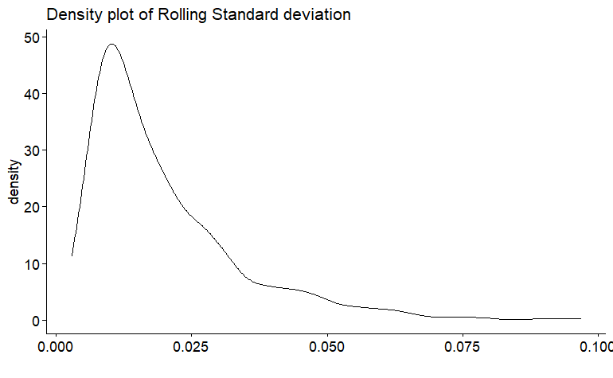

```r
# normality check
normality <- function(input_driver) {

  print(ggdensity(input_driver,
          main = "Density plot of Rolling Standard deviation",
          xlab = ""))

  shapiro.test(input_driver)

}

# function call
normality(final_drivers$roll_std_dev)
```

(*) From the output, the p-value < 0.05 implying that the distribution of the data are significantly different from normal distribution. In other words, we cannot assume the normality. (*)

2. Stationarity test

Augmented Dickey-Fuller (ADF) t-statistic test to find if the series has a unit root (a series with a trend line will have a unit root and result in a large p-value). If the p-value < 0.05 then data is stationary if p-value > 0.05 then data is non-stationary.

Before forform ADF remove NA, replace NA with 0.

```r
# Stationarity check
stationarity <- function(input_driver) {
  input_driver[is.na(input_driver)] <- 0
  tseries::adf.test(input_driver)
}
# function call
stationarity(final_drivers$roll_mean)
```

```
    Augmented Dickey-Fuller Test

data:  input_driver
Dickey-Fuller = -1.7106, Lag order = 9, p-value = 0.7008
alternative hypothesis: stationary
```

roll_mean is non-station due to a high p-value. To test stationary for other drivers replace the other driver with the existing driver and run the function.

3. Correlation coefficient with the target

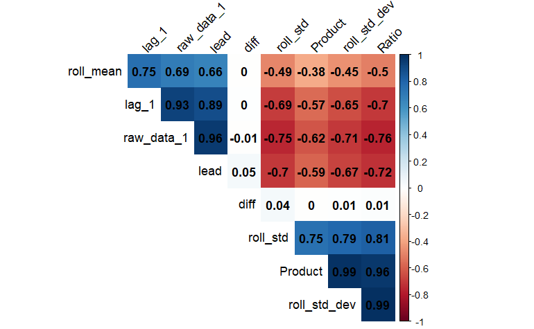

```r
# Correlation coefficient
correlation <- function(input_drivers){

  input_drivers[is.na(input_drivers)] <- 0
  corr_mat=cor(input_drivers)
col <- colorRampPalette(c("#BB4444", "#EE9988", "#FFFFFF", "#77AADD", "#4477AA"))
  return(corrplot(corr_mat, method="color",
         type="upper", order="hclust",
         addCoef.col = "black",
         tl.col="black", tl.srt=45,
         # hide correlation coefficient on the principal diagonal
         diag=FALSE
         ))

}



correlation(final_drivers)
```